# Predicting Water Quality using Machine Learning

Vincent Katunga-Phiri

2024-12-11

## Introduction

Water is an essential component of life and the earth’s ecosystems. Increased urbanisation and industrialisation have increased water demand while also reducing water quality (Ejigu, 2021). Oceans, lakes, dams, and rivers are the primary water sources for a variety of applications, including drinking, irrigation, and public use. According to Spellman (2008), water quality includes the physical, chemical, and biological properties of water. Potable water is defined as water that is safe to drink, tastes good, and is appropriate for domestic use (Spellman, 2008). This project aims to predict potable water using machine learning techniques based on available water parameters such as ph, hardness, solids, chloramines, sulphate, conductivity, organic carbon, trihalomethanes, and turbidity.

## Methods

**Dataset Description**  
The dataset has 3276 observations and 10 variables. the variables include; `ph`: An indicator of acidic or alkaline condition of water status. `Hardness`: The concentration of calcium and magnesium ions in water, which affects its ability to lather with soap. `Solids`: The total dissolved solids in water, indicating the amount of inorganic and organic substances dissolved in it. `Chloramines`: Compounds of chlorine and ammonia used as a disinfectant in water treatment to control bacteria and pathogens. `Sulfate`: The concentration of sulfate ions (SO₄²⁻) in water, which can affect taste and, at high levels, cause laxative effects. `Conductivity`: A measure of water’s ability to conduct electricity, which reflects the concentration of dissolved salts or ions. `Organic_carbon`: The amount of organic compounds in water, often used as an indicator of water quality and pollution. `Trihalomethanes`: The cloudiness or haziness of water caused by suspended particles, which can affect aesthetic quality and microbial safety. `Potability`: An indicator of whether water is safe to drink, considering its chemical, physical, and biological quality.

```
## 'data.frame':    3276 obs. of  10 variables:
##  $ ph             : num  NA 3.72 8.1 8.32 9.09 ...
##  $ Hardness       : num  205 129 224 214 181 ...
##  $ Solids         : num  20791 18630 19910 22018 17979 ...
##  $ Chloramines    : num  7.3 6.64 9.28 8.06 6.55 ...
##  $ Sulfate        : num  369 NA NA 357 310 ...
##  $ Conductivity   : num  564 593 419 363 398 ...
##  $ Organic_carbon : num  10.4 15.2 16.9 18.4 11.6 ...
##  $ Trihalomethanes: num  87 56.3 66.4 100.3 32 ...
##  $ Turbidity      : num  2.96 4.5 3.06 4.63 4.08 ...
##  $ Potability     : int  0 0 0 0 0 0 0 0 0 0 ...
```

```
##        ph            Hardness          Solids         Chloramines
##  Min.   : 0.000   Min.   : 47.43   Min.   :  320.9   Min.   : 0.352
##  1st Qu.: 6.093   1st Qu.:176.85   1st Qu.:15666.7   1st Qu.: 6.127
##  Median : 7.037   Median :196.97   Median :20927.8   Median : 7.130
##  Mean   : 7.081   Mean   :196.37   Mean   :22014.1   Mean   : 7.122
##  3rd Qu.: 8.062   3rd Qu.:216.67   3rd Qu.:27332.8   3rd Qu.: 8.115
##  Max.   :14.000   Max.   :323.12   Max.   :61227.2   Max.   :13.127
##  NA's   :491
##     Sulfate       Conductivity   Organic_carbon  Trihalomethanes
##  Min.   :129.0   Min.   :181.5   Min.   : 2.20   Min.   :  0.738
##  1st Qu.:307.7   1st Qu.:365.7   1st Qu.:12.07   1st Qu.: 55.845
##  Median :333.1   Median :421.9   Median :14.22   Median : 66.622
##  Mean   :333.8   Mean   :426.2   Mean   :14.28   Mean   : 66.396
##  3rd Qu.:360.0   3rd Qu.:481.8   3rd Qu.:16.56   3rd Qu.: 77.337
##  Max.   :481.0   Max.   :753.3   Max.   :28.30   Max.   :124.000
##  NA's   :781                                     NA's   :162
##    Turbidity       Potability
##  Min.   :1.450   Min.   :0.0000
##  1st Qu.:3.440   1st Qu.:0.0000
##  Median :3.955   Median :0.0000
##  Mean   :3.967   Mean   :0.3901
##  3rd Qu.:4.500   3rd Qu.:1.0000
##  Max.   :6.739   Max.   :1.0000
##
```

From the output above, we can notice that some variables have a huge difference between the 3rd quantile and the maximum value in the dataset indicating some outliers.

```
##         ph Hardness   Solids Chloramines  Sulfate Conductivity Organic_carbon
## 1       NA 204.8905 20791.32    7.300212 368.5164     564.3087      10.379783
## 2 3.716080 129.4229 18630.06    6.635246       NA     592.8854      15.180013
## 3 8.099124 224.2363 19909.54    9.275884       NA     418.6062      16.868637
## 4 8.316766 214.3734 22018.42    8.059332 356.8861     363.2665      18.436524
## 5 9.092223 181.1015 17978.99    6.546600 310.1357     398.4108      11.558279
## 6 5.584087 188.3133 28748.69    7.544869 326.6784     280.4679       8.399735
##   Trihalomethanes Turbidity Potability
## 1        86.99097  2.963135          0
## 2        56.32908  4.500656          0
## 3        66.42009  3.055934          0
## 4       100.34167  4.628771          0
## 5        31.99799  4.075075          0
## 6        54.91786  2.559708          0
```

The output above is just a glimpse of the 6 first observations in the dataset. NA values can be seen.

**Missing Data**  
Since we have seen that our dataset comprises of missing values, the figure below is a visual representation of the extent of missingness in the dataset. There are 1434 observations with missing values in either of the variables in the dataset.

```
## [1] 1434
```

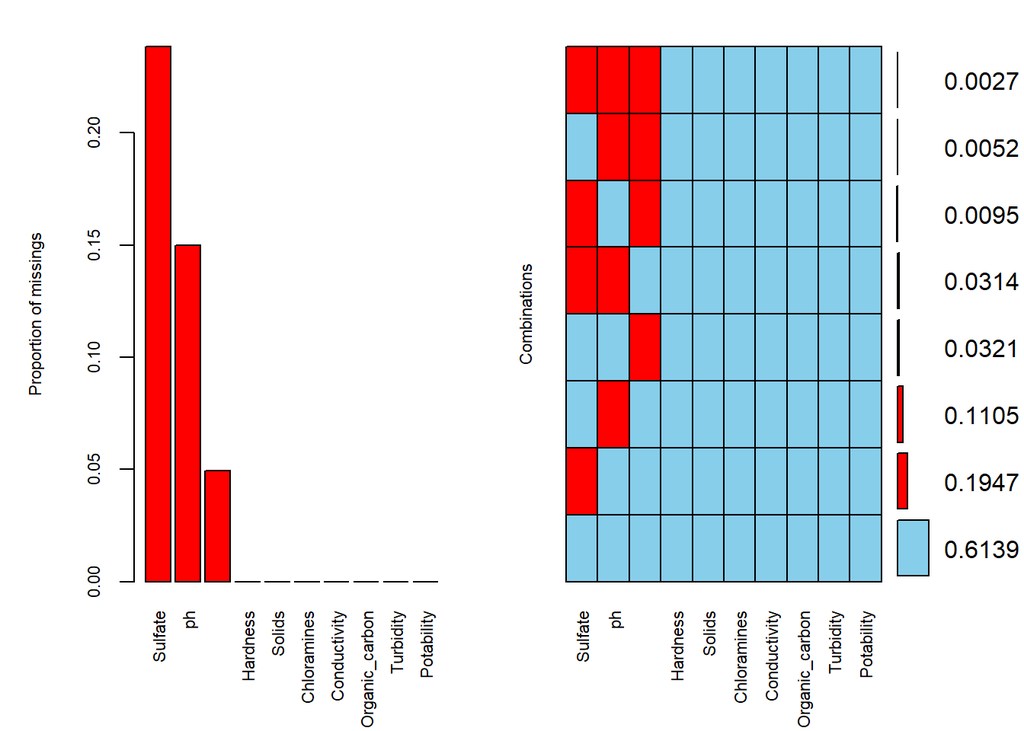

```
##
##  Variables sorted by number of missings:
##         Variable      Count
##          Sulfate 0.23840049
##               ph 0.14987790
##  Trihalomethanes 0.04945055
##         Hardness 0.00000000
##           Solids 0.00000000
##      Chloramines 0.00000000
##     Conductivity 0.00000000
##   Organic_carbon 0.00000000
##        Turbidity 0.00000000
##       Potability 0.00000000
```

From the chart above, the variables `Sulfate` and `ph` have the highest number of missing values with over 20% missing values for `Sulfate` and 15% for `ph`. Looking at this, there is need for dealing with the missing data, either by imputing with the mean, mode, median or using a complex algorithm for imputation like k Nearest Neighbors (KNN) algorithm.

### Explaratory Analysis

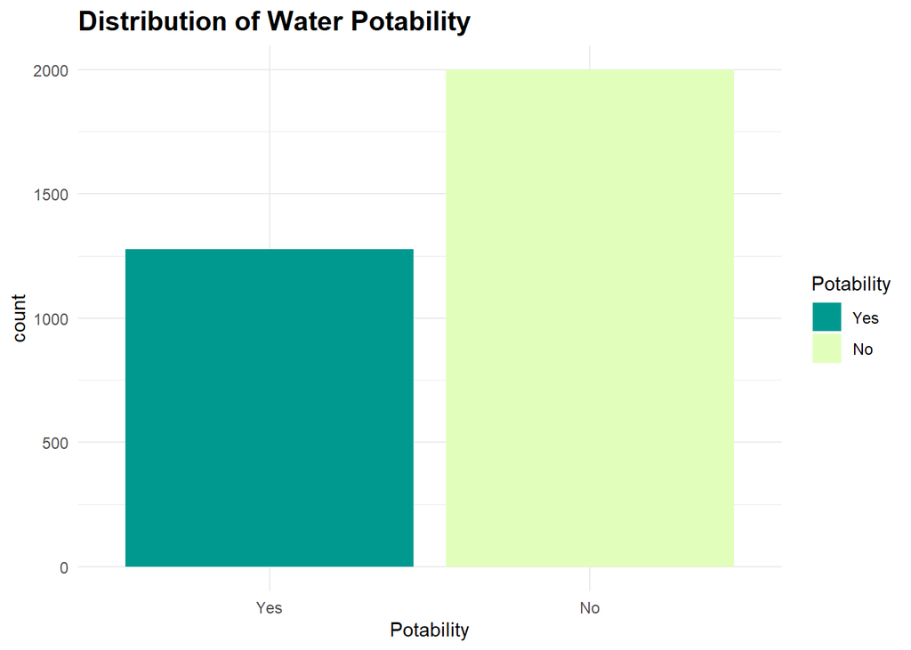

**Distribution of the water parameters against Potability**

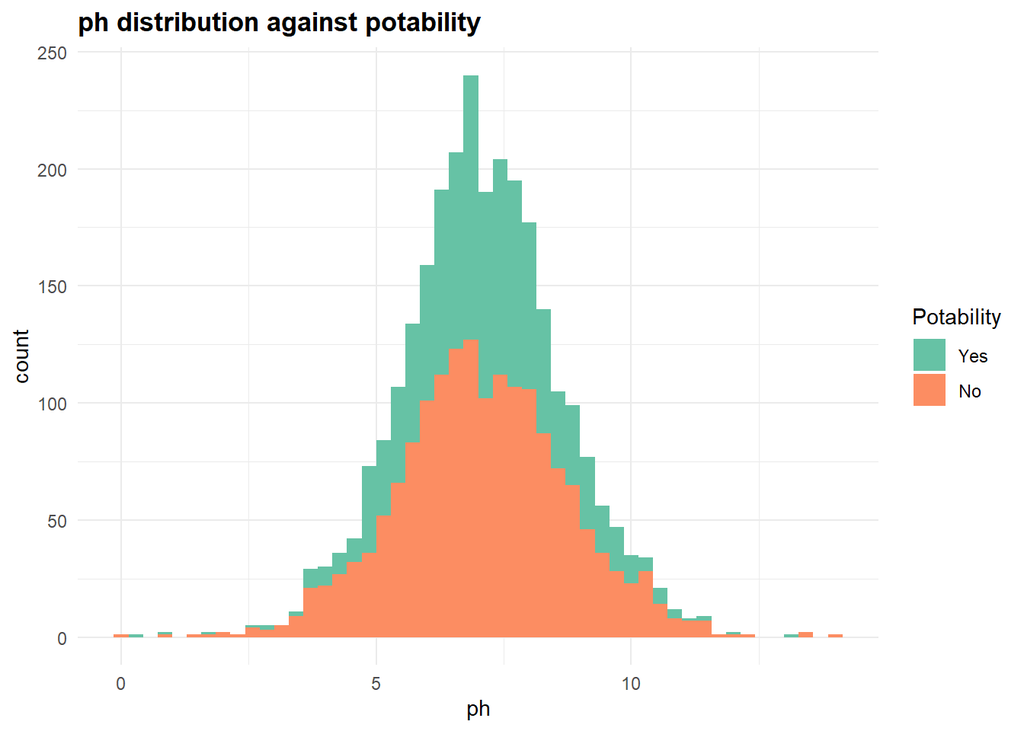

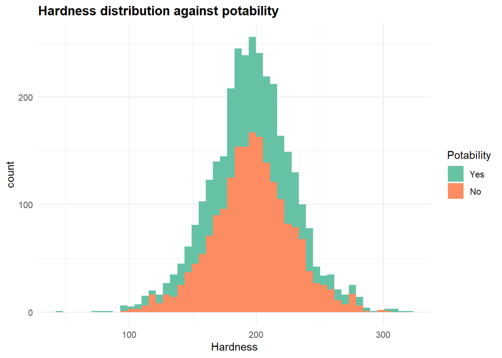

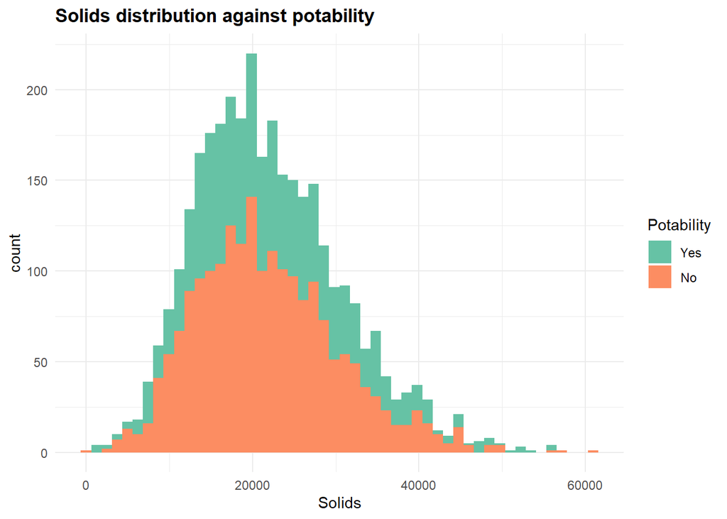

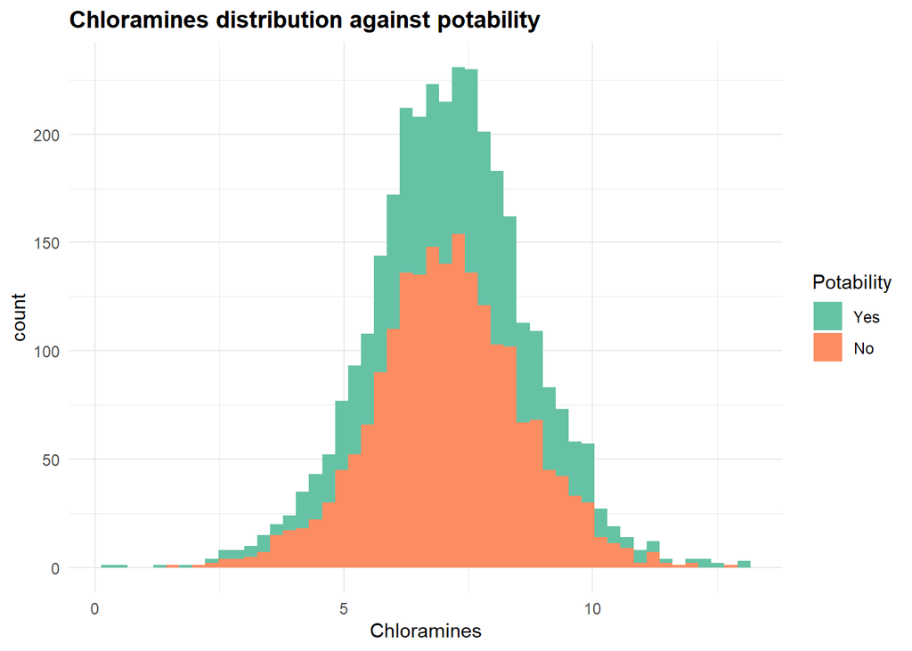

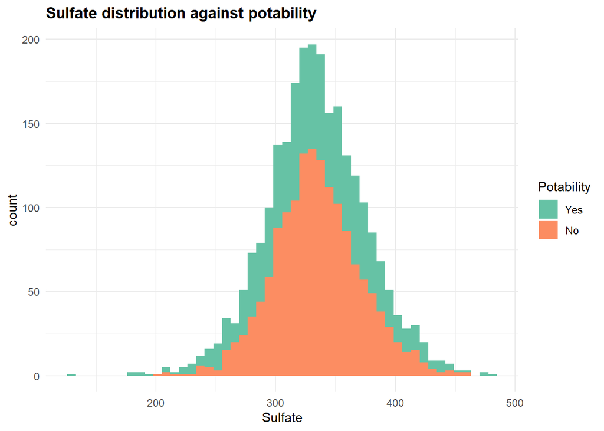

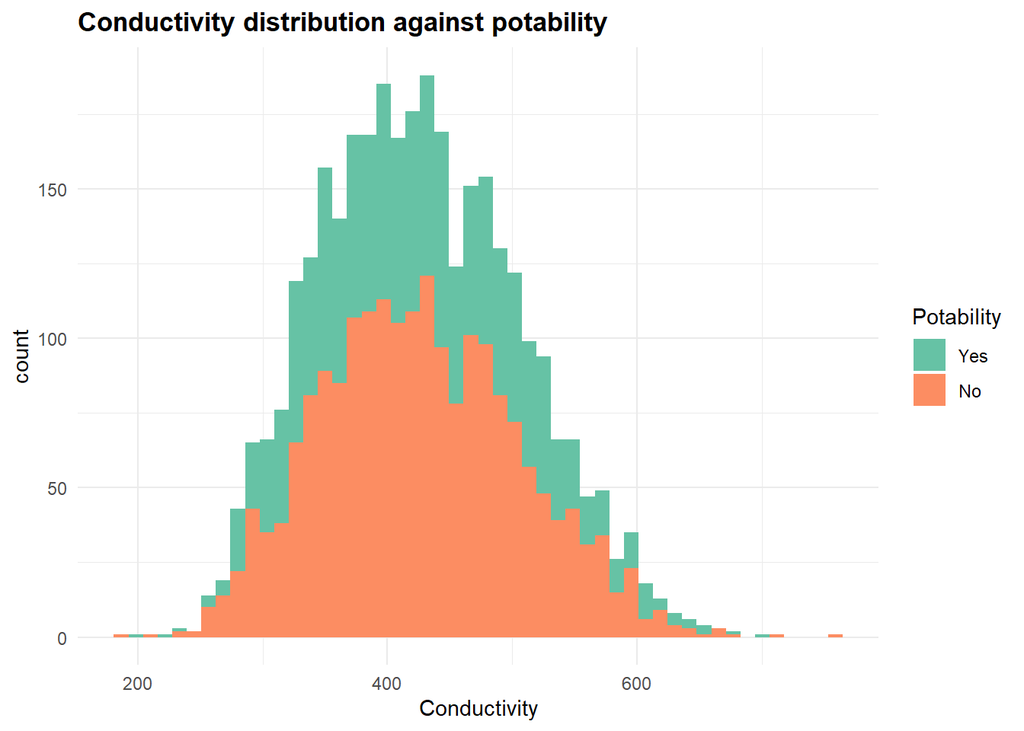

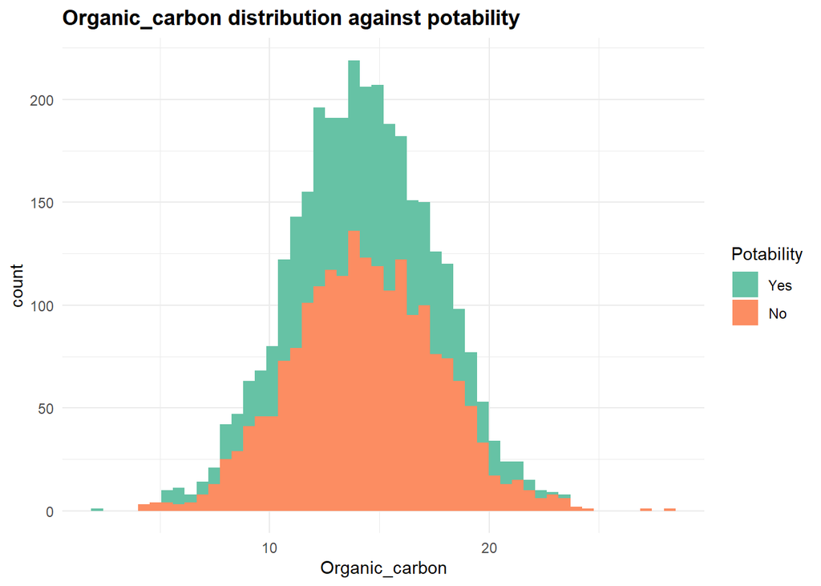

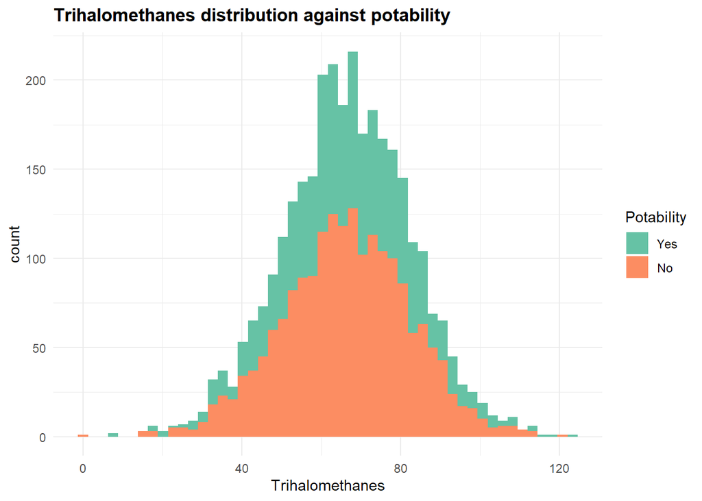

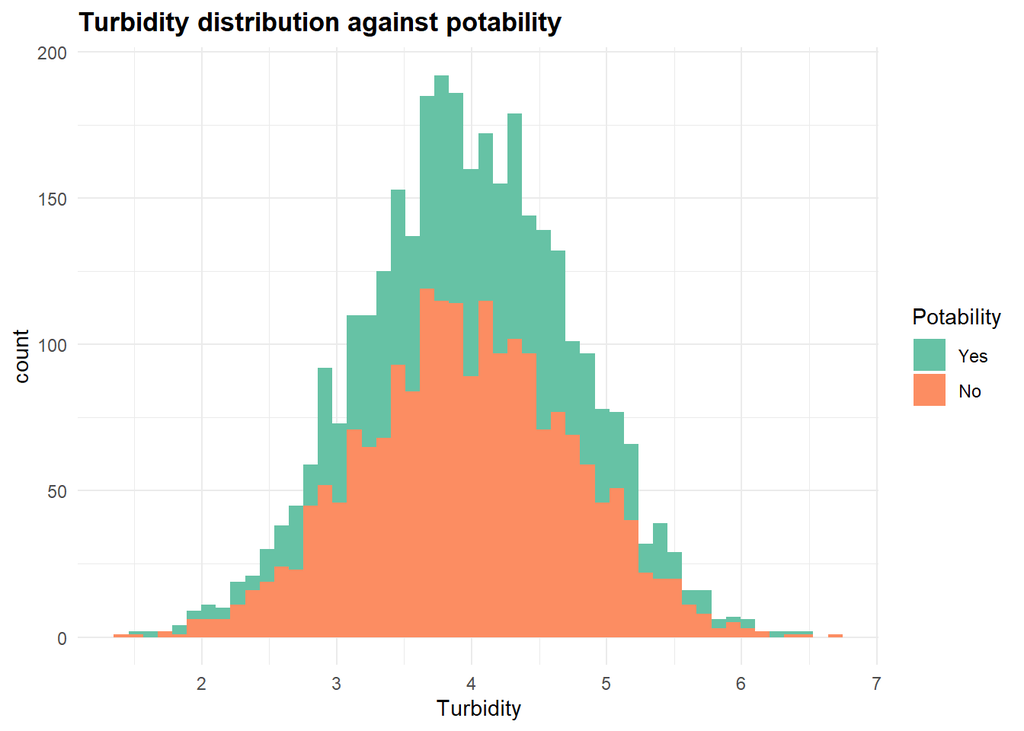

The output indicates that nearly all variables in the dataset show a normal distribution. Despite the presence of outliers, imputation utilising mean, mode, or median will be easily performed due to the normal distribution of the data. It also improves model efficacy. In nearly all distributions, the spread is similar, indicating comparable variability of parameter values for potable and non-potable water. Furthermore, all distributions indicate that the dataset contains a greater quantity of non-potable water compared to potable water. The distributions for both potable and non-potable water appear to be centred at comparable levels across all distributions.

The box plots below confirms our observation that the variability of the data in both potable and non-potable is similar e.g., the mean looks the same in all distributions. We can also notice outliers in the dataset. The quantiles also look similar.

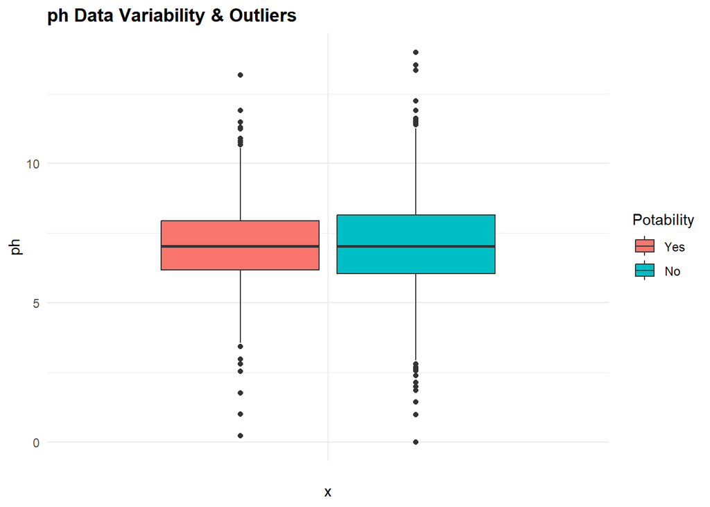

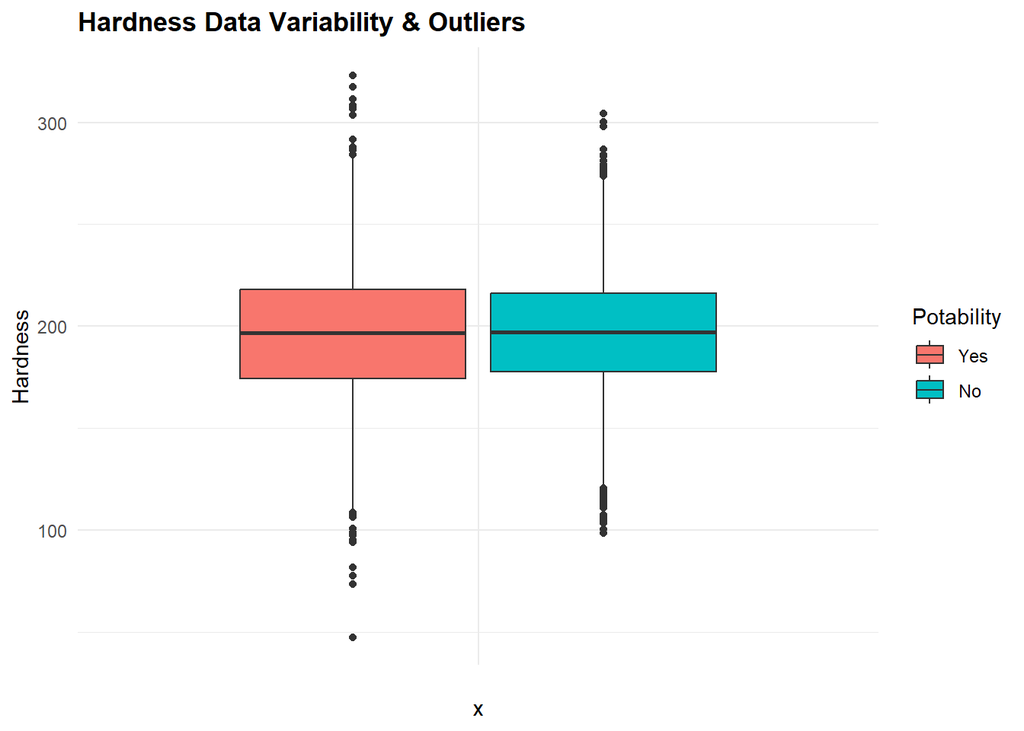

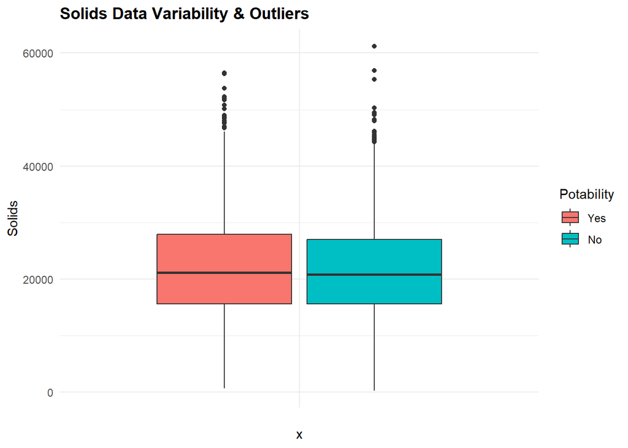

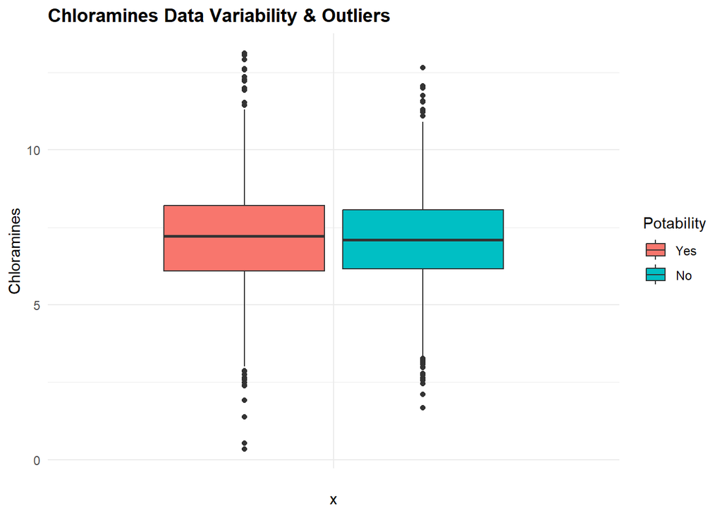

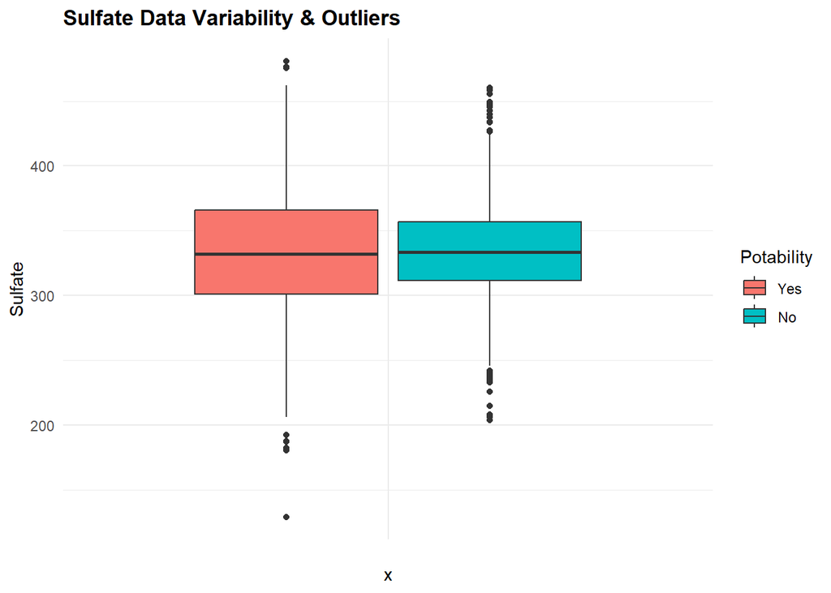

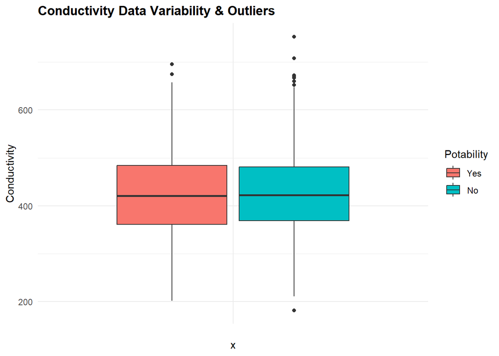

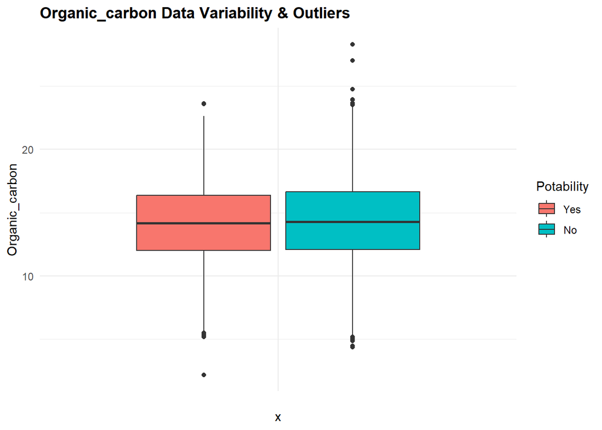

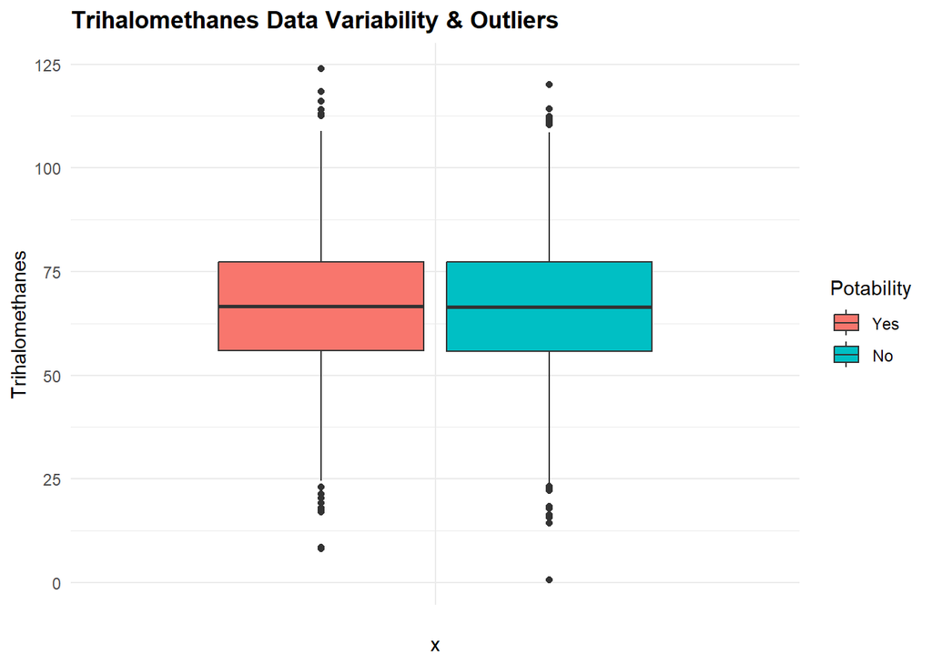

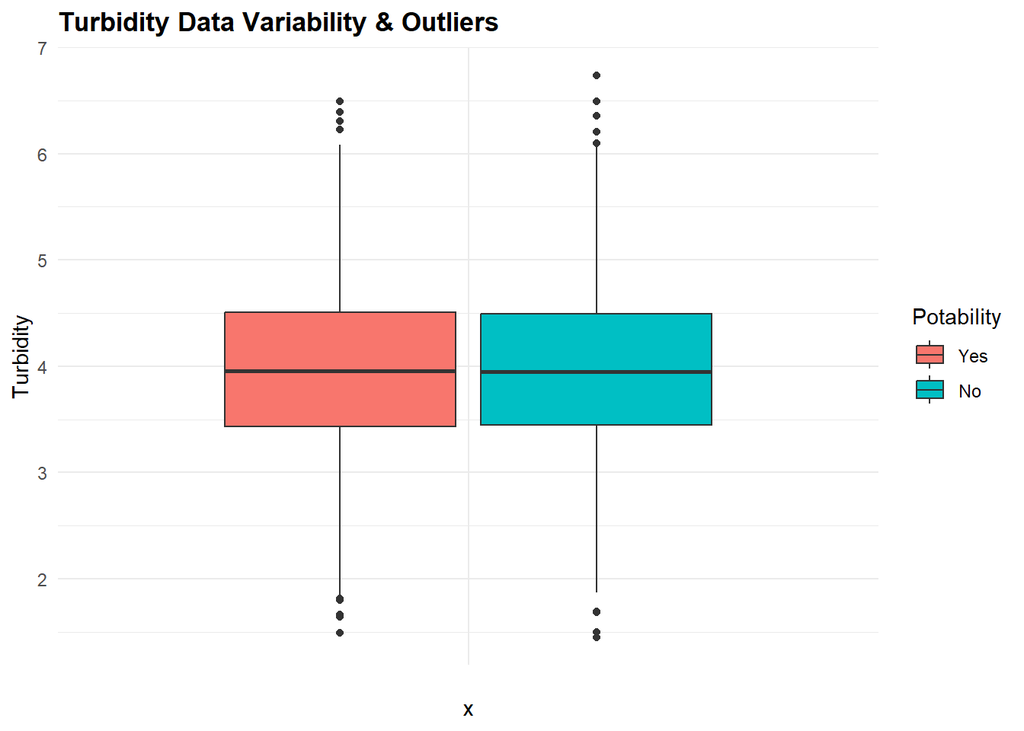

```
##        ph            Hardness          Solids         Chloramines
##  Min.   : 0.000   Min.   : 47.43   Min.   :  320.9   Min.   : 0.352
##  1st Qu.: 6.278   1st Qu.:176.85   1st Qu.:15666.7   1st Qu.: 6.127
##  Median : 7.000   Median :196.97   Median :20927.8   Median : 7.130
##  Mean   : 7.069   Mean   :196.37   Mean   :22014.1   Mean   : 7.122
##  3rd Qu.: 7.870   3rd Qu.:216.67   3rd Qu.:27332.8   3rd Qu.: 8.115
##  Max.   :14.000   Max.   :323.12   Max.   :61227.2   Max.   :13.127
##     Sulfate       Conductivity   Organic_carbon  Trihalomethanes
##  Min.   :129.0   Min.   :181.5   Min.   : 2.20   Min.   :  0.738
##  1st Qu.:317.1   1st Qu.:365.7   1st Qu.:12.07   1st Qu.: 56.648
##  Median :334.0   Median :421.9   Median :14.22   Median : 66.000
##  Mean   :333.8   Mean   :426.2   Mean   :14.28   Mean   : 66.377
##  3rd Qu.:350.4   3rd Qu.:481.8   3rd Qu.:16.56   3rd Qu.: 76.667
##  Max.   :481.0   Max.   :753.3   Max.   :28.30   Max.   :124.000
##    Turbidity     Potability
##  Min.   :1.450   Yes:1278
##  1st Qu.:3.440   No :1998
##  Median :3.955
##  Mean   :3.967
##  3rd Qu.:4.500
##  Max.   :6.739
```

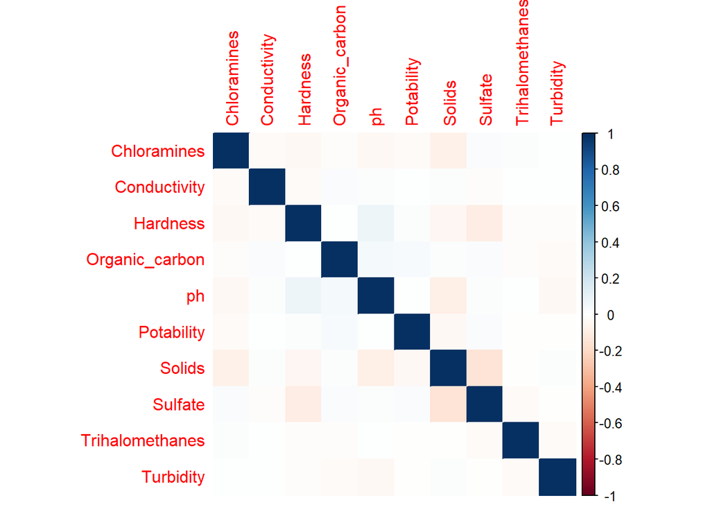

The correlation matrix above clearly indicates the absence of correlation among the variables.

**Modelling Approaches**  
For this project, Random Forest and K Nearest Neighbors were used to predict water potability. These models take into account that the dependent variable be a factor with more than one level (Han et al., 2022). According to (Breiman, 2001) is a classification and regression model that uses the decision tree model approach to create a forest consisting of multiple decision trees. K Nearest Neighbors is also a classification machine learning model that classifies a data point by determining the predominant class among its k nearest neighbours in the feature space (Cover & Hart, 1967).

**Data Split**  
The caret package was utilised to partition the data according to the 80/20 rule, allocating 80% for training and 20% for testing. Set.seed is used to ensure the reproducibility of the model.

```r
set.seed(123)
sample <- createDataPartition(water_quality$Potability, p = 0.8, list = FALSE)
train_data <- water_quality[sample, ]
test_data <- water_quality[-sample, ]
```

*Random Forest Model*

```r
train_control <- trainControl(method = "cv", number = 2)
rf_model <- train(Potability ~ ., data = train_data, method = "rf", trControl = train_control) #The model
rf_predict <- predict(rf_model, test_data) #Predicting the test data
test_data$Potability_pred <- rf_predict
```

*KNN Model*

```r
knn_model <- train(Potability ~ ., data = train_data, method = "knn") #The model
knn_predict <- predict(knn_model, test_data) #Predicting the test data
test_data$Potability_pred <- knn_predict
```

## Results

According to Han et al. (2022), when dealing with nominal dependent variables, evaluation metrics such as accuracy, precision, recall, and F1-Score should be utilised instead of the Root Mean Squared Error (RMSE). Given that the dependent variable `potability` is nominal, the following evaluation metrics will be employed.

```r
rf_confusionMatrix <- table(test_data$Potability, test_data$Potability_pred)
rf_confusionMatrix
```

```
##
##       Yes  No
##   Yes  60 195
##   No   76 323
```

```r
rf_classification_accuracy <- sum(diag(rf_confusionMatrix)/sum(rf_confusionMatrix))
rf_classification_accuracy
```

```
## [1] 0.5856269
```

The code below extracts the elements of the confusion matrix

```r
#Elements of confusion matrix
rf_TN <- rf_confusionMatrix [1,1]
rf_FP <- rf_confusionMatrix [1,2]
rf_FN <- rf_confusionMatrix [2,1]
rf_TP <- rf_confusionMatrix [2,2]
```

```r
rf_precision <- rf_TP/(rf_TP+rf_FP)
rf_precision
```

```
## [1] 0.6235521
```

```r
rf_recall <- rf_TP/(rf_TP+rf_FN)
rf_recall
```

```
## [1] 0.8095238
```

```r
rf_f1_score <- 2*(rf_precision * rf_recall)/(rf_precision + rf_recall)
rf_f1_score
```

```
## [1] 0.7044711
```

```r
knn_confusionMatrix <- table(test_data$Potability, test_data$Potability_pred)
knn_confusionMatrix
```

[output not shown]

```r
knn_classification_accuracy <- sum(diag(knn_confusionMatrix)/sum(knn_confusionMatrix))
knn_classification_accuracy
```

```
## [1] 0.5856269
```

The code below extracts the elements of the confusion matrix

```r
knn_TN <- knn_confusionMatrix [1,1]
knn_FP <- knn_confusionMatrix [1,2]
knn_FN <- knn_confusionMatrix [2,1]
knn_TP <- knn_confusionMatrix [2,2]
```

```r
knn_precision <- knn_TP/(knn_TP+knn_FP)
knn_precision
```

```
## [1] 0.6235521
```

```r
knn_recall <- knn_TP/(knn_TP+knn_FN)
knn_recall
```

```
## [1] 0.8095238
```

```r
knn_f1_score <- 2*(knn_precision * knn_recall)/(knn_precision + knn_recall)
knn_f1_score
```

```
## [1] 0.7044711
```

## References

1. Breiman, L. (2001). Random Forests. Machine Learning, 45(1), 5–32. https://doi.org/10.1023/A:1010933404324
2. Cover, T., & Hart, P. (1967). Nearest neighbor pattern classification. IEEE Transactions on Information Theory, 13(1), 21–27. https://doi.org/10.1109/TIT.1967.1053964
3. Han, J., Pei, J., & Tong, H. (2022). Data mining: Concepts and techniques. Morgan kaufmann.
4. Harper, F. M., & Konstan, J. A. (2015). The movielens datasets: History and context. Acm Transactions on Interactive Intelligent Systems (Tiis), 5(4), 1–19.
5. Karunasingha, D. S. K. (2022). Root mean square error or mean absolute error? Use their ratio as well. Information Sciences, 585, 609–629. https://doi.org/10.1016/j.ins.2021.11.036
6. Witten, I., Frank, E., Hall, M. A., & Pal, C. J. (2016). Data Mining: Practical Machine Learning Tools and Techniques.